# EEG Data Visualization

> EEG data visualization is useful to find peaks and troughs in the ERP channel data to determine differences in activity patterns. Activity patterns will tell you which parts of the brain are most activated and when to allow interpretation of any underlying processes in the brain.

```python
#Import packages
import numpy as np
import pandas as pd
import matplotlib.pyplot as plt
import seaborn as sns
import mne
```

Uploading the participant demographics for the study where group 1 are the patients with Schizophrenia and group 0 are the control subjects. To simplify data manipulation, I selected two participants from the control group and two participants from the patient group. I controlled most demographic variables by selecting all male subjects within a small age range at the same level of education.

```python
dem = pd.read_csv('demographic.csv',index_col='subject')
```

```python
type(dem)
```

```
pandas.core.frame.DataFrame
```

```python
dem.loc[[1,8,69,79],:]
```

| subject | group | gender | age | education |
| --- | --- | --- | --- | --- |
| 1 | 0 | M | 44 | 16.0 |
| 8 | 0 | M | 45 | 16.0 |
| 69 | 1 | M | 47 | 16.0 |
| 79 | 1 | M | 37 | 16.0 |

Read in the data for each subject using **pd.read_csv()**, indexing the 'time_ms' column:

```python
s1_neurons = pd.read_csv('subject1.csv',index_col='time_ms')
s8_neurons = pd.read_csv('subject8.csv',index_col='time_ms')
s69_neurons = pd.read_csv('subject69.csv',index_col='time_ms')
s79_neurons = pd.read_csv('subject79.csv',index_col='time_ms')
```

```python
s1_neurons.head()
```

| time_ms | subject | condition | Fz | FCz | Cz | FC3 | FC4 | C3 | C4 | CP3 | CP4 |
| --- | --- | --- | --- | --- | --- | --- | --- | --- | --- | --- | --- |
| -1500.0000 | 1 | 1 | 5.533701 | 5.726507 | 5.469535 | 5.386723 | 4.588875 | 6.560092 | 4.542811 | 5.397492 | 5.103695 |
| -1499.0234 | 1 | 1 | 5.651489 | 5.837326 | 5.773131 | 5.627975 | 4.822217 | 6.739976 | 4.811770 | 5.541357 | 5.379273 |
| -1498.0469 | 1 | 1 | 5.717580 | 5.932924 | 5.948466 | 5.826460 | 4.979647 | 7.026199 | 5.053779 | 5.634972 | 5.600504 |
| -1497.0703 | 1 | 1 | 5.703267 | 5.968103 | 5.851512 | 5.812192 | 4.992899 | 6.940671 | 5.106650 | 5.543577 | 5.589775 |
| -1496.0938 | 1 | 1 | 5.571578 | 5.917541 | 5.812808 | 5.744715 | 4.963338 | 6.726491 | 5.158073 | 5.454069 | 5.614092 |

```python
s69_neurons.head()
```

| time_ms | subject | condition | Fz | FCz | Cz | FC3 | FC4 | C3 | C4 | CP3 | CP4 |
| --- | --- | --- | --- | --- | --- | --- | --- | --- | --- | --- | --- |
| -1500.0000 | 69 | 1 | 6.663418 | 8.199668 | 10.274413 | 6.543800 | 4.954367 | 8.642129 | 4.432416 | 8.320644 | 6.206152 |
| -1499.0234 | 69 | 1 | 6.743988 | 8.292320 | 10.248171 | 6.647655 | 5.213742 | 8.736359 | 4.579955 | 8.352060 | 6.280123 |
| -1498.0469 | 69 | 1 | 6.809091 | 8.452699 | 10.307729 | 6.836936 | 5.211765 | 8.743156 | 4.835015 | 8.387632 | 6.411942 |
| -1497.0703 | 69 | 1 | 6.780490 | 8.498483 | 10.416002 | 6.967274 | 5.121694 | 8.779858 | 4.872488 | 8.350168 | 6.557682 |
| -1496.0938 | 69 | 1 | 6.761199 | 8.554934 | 10.519036 | 6.882544 | 5.243528 | 8.720744 | 4.894440 | 8.213531 | 6.703975 |

Use the **.concat()** function to stack the subject group DataFrames row-wise, while combining the ERP data for both conditions using groupby to reflect a slightly more representative sample. Also dropping the subject column as it no longer holds after finding the average ERP, and all electrodes except for the one of interest (Cz).

```python
ctrl_data = pd.concat([s1_neurons,s8_neurons]).groupby(['condition','time_ms']).mean()
ctrl_data = ctrl_data.drop(columns=['subject','Fz','FCz','FC3','FC4','C3','C4',
                                    'CP3','CP4'])
ctrl_data
```

| condition | time_ms | Cz |
| --- | --- | --- |
| 1 | -1500.0000 | 4.831956 |
|  | -1499.0234 | 4.959063 |
|  | -1498.0469 | 4.998615 |
|  | -1497.0703 | 4.933554 |
|  | -1496.0938 | 4.939637 |
| ... | ... | ... |
| 2 | 1495.1172 | 0.483377 |
|  | 1496.0938 | 0.582908 |
|  | 1497.0703 | 0.625822 |
|  | 1498.0469 | 0.669393 |
|  | 1499.0234 | 0.678301 |

6144 rows × 1 columns

```python
patient_data = pd.concat([s69_neurons,s79_neurons]).groupby(['condition','time_ms']).mean()
patient_data = patient_data.drop(columns=['subject','Fz','FCz','FC3','FC4','C3','C4',
                                      'CP3','CP4'])
patient_data
```

| condition | time_ms | Cz |
| --- | --- | --- |
| 1 | -1500.0000 | 5.710266 |
|  | -1499.0234 | 5.673716 |
|  | -1498.0469 | 5.807043 |
|  | -1497.0703 | 5.898068 |
|  | -1496.0938 | 5.803092 |
| ... | ... | ... |
| 2 | 1495.1172 | 4.238880 |
|  | 1496.0938 | 4.142067 |
|  | 1497.0703 | 4.046102 |
|  | 1498.0469 | 4.107701 |
|  | 1499.0234 | 4.061736 |

6144 rows × 1 columns

Disassembling hierarchical indexes to facilitate visualizations; printing a random sample of the data:

```python
ctrl_data.reset_index(inplace=True)
ctrl_data.sample(10)
```

|  | index | condition | time_ms | Cz |
| --- | --- | --- | --- | --- |
| 5208 | 5208 | 2 | 585.9375 | 1.247925 |
| 203 | 203 | 1 | -1301.7578 | 3.670803 |
| 4672 | 4672 | 2 | 62.5000 | -1.576569 |
| 3319 | 3319 | 2 | -1258.7891 | -0.059075 |
| 3618 | 3618 | 2 | -966.7969 | -2.344174 |
| 3853 | 3853 | 2 | -737.3047 | -0.271185 |
| 4117 | 4117 | 2 | -479.4922 | -0.879068 |
| 73 | 73 | 1 | -1428.7109 | 3.634921 |
| 3165 | 3165 | 2 | -1409.1797 | -0.812946 |
| 2834 | 2834 | 1 | 1267.5781 | 2.827822 |

```python
patient_data.reset_index(inplace=True)
patient_data.sample(10)
```

|  | index | condition | time_ms | Cz |
| --- | --- | --- | --- | --- |
| 5340 | 5340 | 2 | 714.8438 | -1.709054 |
| 5507 | 5507 | 2 | 877.9297 | 0.601703 |
| 4147 | 4147 | 2 | -450.1953 | 2.270329 |
| 4145 | 4145 | 2 | -452.1484 | 1.646190 |
| 1871 | 1871 | 1 | 327.1484 | 5.351454 |
| 5148 | 5148 | 2 | 527.3438 | 0.173034 |
| 5026 | 5026 | 2 | 408.2031 | -0.549806 |
| 2261 | 2261 | 1 | 708.0078 | 7.325090 |
| 4657 | 4657 | 2 | 47.8516 | -1.457094 |
| 1575 | 1575 | 1 | 38.0859 | 0.426361 |

Creating separate line plots with the control and patient data to compare ERP patterns:

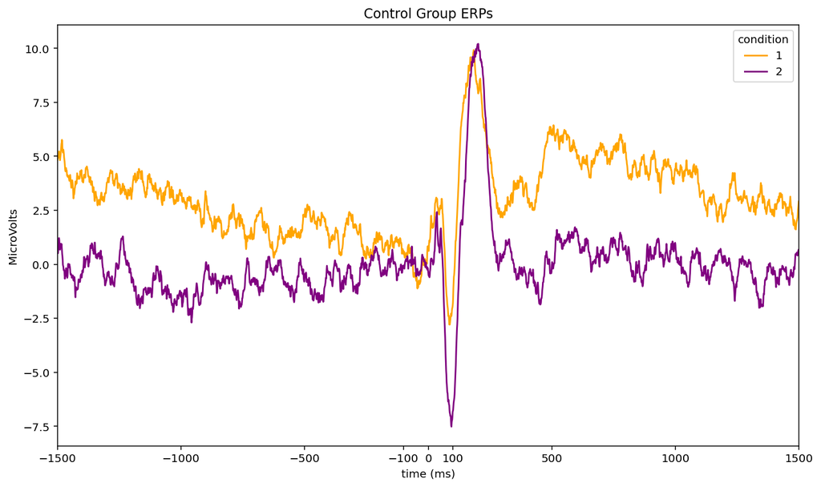

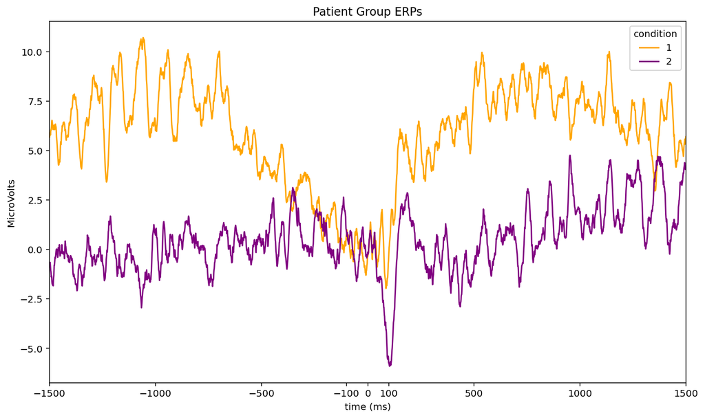

```python
import seaborn as sns

ax = sns.lineplot(data=ctrl_data, x='time_ms', y='Cz', hue='condition',palette=['orange','purple'])
ax.set(ylabel='MicroVolts', xlabel='time (ms)',title='Control Group ERPs')
ax.set(xlim=(-1500,1500), #Set the limit and ticks of the
 xticks=[-1500,-1000,-500,-100,0,100,500,1000,1500])
plt.show()

ax = sns.lineplot(data=patient_data, x='time_ms', y='Cz', hue='condition',palette=['orange','purple'])
ax.set(ylabel='MicroVolts', xlabel='time (ms)',title='Patient Group ERPs')
ax.set(xlim=(-1500,1500), #Set the limit and ticks of the
 xticks=[-1500,-1000,-500,-100,0,100,500,1000,1500])
plt.show()
```

> The study found that when comparing condition 1 to condition 2, the control group experienced a negative deflection at N100, found approximately 100ms after stimulus onset, however the patient group did not experience such a deflection. Although it is not necessariily clear whether the results are significant when viewing the group data from only two participants for each group, there is a visible difference in the N100 deflection between groups, where it appears that the patient group experiences a less pronounce delfection at N100 compared to the control group.